## Exercício 1

Os dados deste exercício são registros de três medidas da qualidade em vinhos secos de determinada marca, ao final do processo de fermentação: $V_1$ é a densidade relativa (em $g/ml$), $V_2$ é a quantidade de açúcares totais (em $g/l$) e $V_3$ é o $pH$ do vinho.

```r
# Código para gerar os dados
media = c(0.900, 56.000, 3.600)
corr = matrix(c(1, 0.8, 0.5, 0.8, 1, 0.7, 0.5, 0.7, 1), 3, 3, byrow = TRUE)
sigma = matrix(NA,3, 3)
DP.V1 = 0.025;
DP.V2 = 2;
DP.V3 = 0.1
DP = diag(c(DP.V1, DP.V2, DP.V3))
for (i in 1:3) for (j in 1:3) { sigma[i, j] = corr[i, j] * DP[i, i] * DP[j, j]
}
media2 = media
media2[2] = media[2] + 0.5 * sigma[2, 2]
require(MASS)
set.seed(2654);
x = mvrnorm(125, media, sigma)
set.seed(2143);
x[96:100, ] = mvrnorm(5, media2, sigma)
x = round(x, 3)
dados1 <- x
```

- 1. Gráficos de controle para a variabilidade multivariada

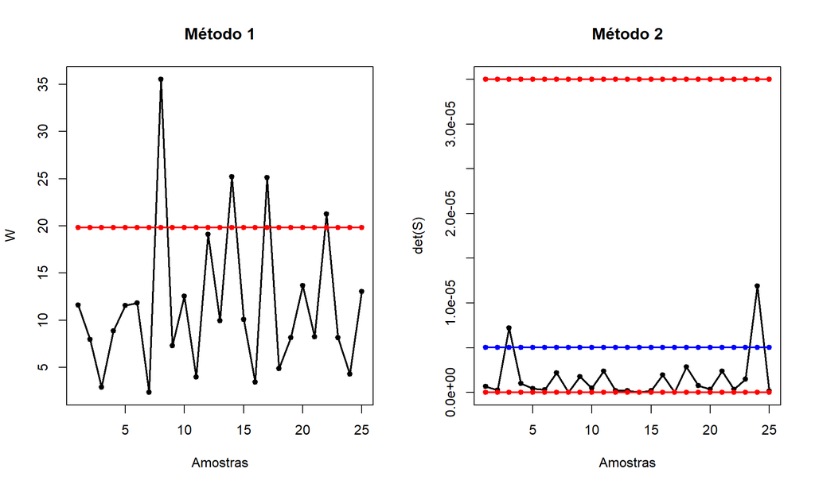

```r
# n = número de observações por amostra
# y = matriz dos dados coletados (cada coluna deve se referir a uma variável)

cvse = function(n, y){
    p = ncol(y); obs = nrow(y); m = obs / n; f = p * n * (log(n) - 1); S = cov(y)
      Sinv = solve(S); det1 = det(S); amostra = matrix(0, n, p); W1 = numeric(m)
      W2 = W1
    for (i in 1:m) {
        amostra = y[(n * i - n + 1):(n * i), ]; Si = cov(amostra); A = (n - 1) * Si
        W1[i] = f + sum(diag(Sinv %*% A)) - n * log(det(A) / det1)
        W2[i] = det(Si)
    }
    time1 = cbind(seq(1, m), seq(1, m)); time2 = cbind(time1, time1)
    LSC1 = qchisq(0.997, p * (p + 1) / 2); z1 = cbind(W1, rep(LSC1, m))
    produto1 = 1; produto2 = 1; x = seq(1, m)
    for (i in 1:p) produto1 = (n - i) * produto1
    for (i in 1:p) produto2 = (n - i + 2) * produto2
    b1 = produto1 / ((n - 1) ^ p)
    b2 = produto1 * (produto2 - produto1) / ((n - 1) ^ (2 * p))
    LIC2 = det1 * (b1 - 3 * sqrt(b2)) / b1; LSC2 = det1 * (b1 + 3 * sqrt(b2)) / b1
    if (LIC2 <= 0) LIC2 = 0
    z2 = cbind(W2, rep(det1, m), rep(LIC2, m), rep(LSC2, m))
    par(mfrow = c(1, 2))
    matplot(time1, z1, type = "o", pch = 20, col = c("black","red"),
        main = "Método 1", xlab = "Amostras", ylab = "W",
        ylim = c(min(z1), max(z1)), lwd = 2, lty = 1)
    matplot(time2, z2, type = "o", col = c("black","blue","red","red"),
        main = "Método 2", xlab = "Amostras", ylab = "det(S)",
        ylim = c(min(z2), max(z2)), lty = 1, lwd = 2, pch = 20)
}

cvse(5, dados1)
```

Na figura acima, foi utilizado o gráfico de controle para a variabilidade multivariada sem especificação, identificou-se no gráfico à esquerda, referente ao Método 1 que há evidências de que as amostras de números 8, 14, 17 e 22 estão fora de controle. Já o gráfico da direita, referente ao Método 2, está sob controle, pode ser um indicativo de que as amostras identificadas como fora de controle pelo Método 1, sejam alarmes falsos.

- 2. Gráfico de controle $T^2$ de Hotelling

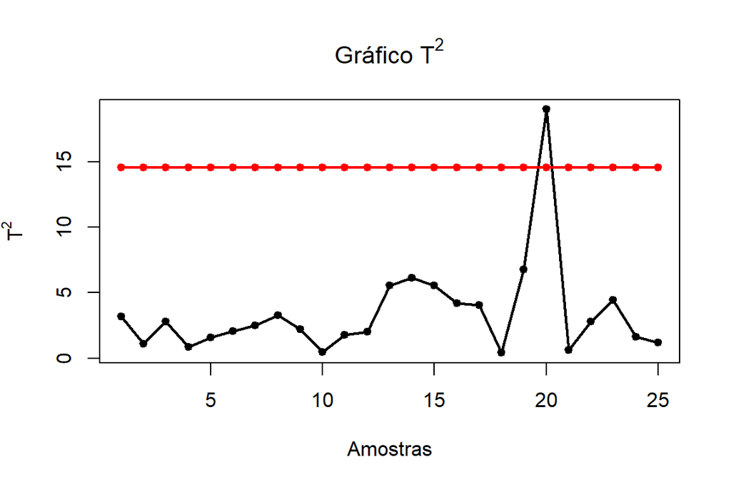

```r
# n = número de observações por amostra
# y = matriz com os dados coletados (cada coluna deve se referir a uma variável)
# etapa = variável dicotômica que deve assumir o valor 1 caso se deseje construir
# o gráfico T2 para identificar as amostras fora de controle e 2, caso se deseje
# estabelecer quais são as estimativas do vetor de médias, da matriz de covariâncias
# e do limite superior de controle, visando o monitoramento futuro do processo.

T2se = function(n, y, etapa){
    p = ncol(y); obs = nrow(y);m = obs / n
    if (n > 1) {
        Sbarra = matrix(0, p, p); media = matrix(NA, m, p)
        amostra = matrix(NA, n, p); t2 = numeric(m)
        for (i in 1:m) {
            amostra = y[(n * i - n + 1):(n * i), ]
            media[i, ] = apply(amostra, 2, mean); S = cov(amostra)
            Sbarra = S + Sbarra
        }
        x2barras = apply(media, 2, mean); Sinv = solve(Sbarra / m)
        for (i in 1:m) {
            z = media[i, ] - x2barras; t2[i] = n * (z %*% Sinv %*% z)
        }
        if (etapa == 1) {
            LSC = p * (m - 1) * (n - 1) * qf(0.997, p, m * n - m - p + 1) / (m * n - m - p + 1)
        }
        if (etapa == 2) {
            LSC = p * (m + 1) * (n - 1) * qf(0.997, p, m * n - m - p + 1) / (m * n - m - p + 1)
        }
        time = cbind(seq(1, m), seq(1, m)); W1 = cbind(t2, rep(LSC, m))
        par(mfrow = c(1, 1))
        matplot(time, W1, type = "o", pch = 20, col = c("black", "red"),
            main = expression(paste("Gráfico " * T ^ 2)), xlab = "Amostras",
            ylab = expression(paste(T ^ 2)),
            ylim = c(min(W1), max(W1)), lty = 1, lwd = 2)
        if (etapa == 2) {
            lista = list(x2barras, Sbarra / m, LSC)
            names(lista) = c("Vetor de Médias",
            "Matriz de Covariâncias",
            "Limite Superior de Controle")
            lista
        }
    } else {
        t2m1 = numeric(m); t2m2 = numeric(m); xbarra = apply(y, 2, mean)
        Sinv1 = solve(cov(y)); V = matrix(NA, m - 1, p)
        for (i in 1:m - 1) V[i, ] = y[i + 1, ] - y[i, ]
        S = (t(V) %*% V) / (2 * (m - 1));   Sinv2 = solve(S)
        for (i in 1:m) {
            z = y[i, ] - xbarra; t2m1[i] = z %*% Sinv1 %*% z
            t2m2[i] = z %*% Sinv2 %*% z
        }
        time = cbind(seq(1, m), seq(1, m))
        if (etapa == 1) {
            LSC = ((m - 1) ^ 2) * qbeta(0.997, p / 2, (m - p - 1) / 2) / m
        }
        if (etapa == 2) {
            LSC = p * (m + 1) * (m - 1) * qf(0.997, p, m - p) / (m * (m - p))
        }
        W1 = cbind(t2m1, rep(LSC, m)); W2 = cbind(t2m2, rep(LSC, m))
        par(mfrow = c(1, 2))
        matplot(time, W1, type = "o", pch = 20, col = c("black", "red"),
            main = expression(paste("Gráfico " * T^2 * " - Estimador 1")),
            xlab = "Amostras", ylab = expression(paste(T ^ 2)),
            ylim = c(min(W1), max(W1)), lty = 1, lwd = 2)
        matplot(time, W2, type = "o", pch = 20, col = c("black", "red"),
            main = expression(paste("Gráfico " * T^2 * " - Estimador 2")),
            xlab = "Amostras", ylab = expression(paste(T ^ 2)),
            ylim = c(min(W2), max(W2)), lty = 1, lwd = 2)
        if (etapa == 2) {
            lista = list(xbarra, S, LSC)
            names(lista) = c("Vetor de Médias",
            "Matriz de Covariâncias",
            "Limite Superior de Controle")
            lista
        }
    }
}

T2se(5, dados1, 1)
```

Com a intenção de verificar se há amostras fora de controle (etapa 1), foi utilizado o gráfico $T^2$ de Hotelling sem especificação. Observou-se que a amostra de número 20 ultrapassou o Limite Superior de Controle, dessa forma, este processo encontra-se fora de controle.

- 3. Gráfico de controle $T^2$ de Hotelling

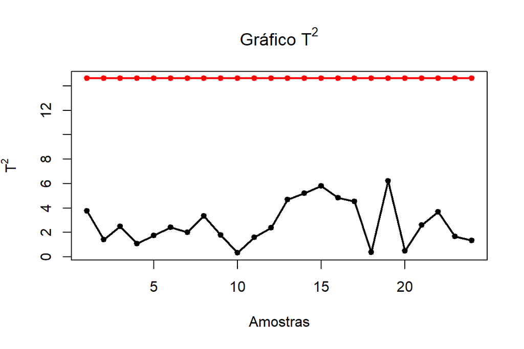

```r
# n = número de observações por amostra
# y = matriz com os dados coletados (cada coluna deve se referir a uma variável)
# etapa = variável dicotômica que deve assumir o valor 1 caso se deseje construir
# o gráfico T2 para identificar as amostras fora de controle e 2, caso se deseje
# estabelecer quais são as estimativas do vetor de médias, da matriz de covariâncias
# e do limite superior de controle, visando o monitoramento futuro do processo.

dados11 <- dados1[-(96:100), ]

T2se(5, dados11, 1)
```

Após a retirada da amostra de número 20, ainda na etapa 1, nota-se que o processo está sob controle.

- 4. Gráfico de controle $T^2$ de Hotelling (etapa 2)

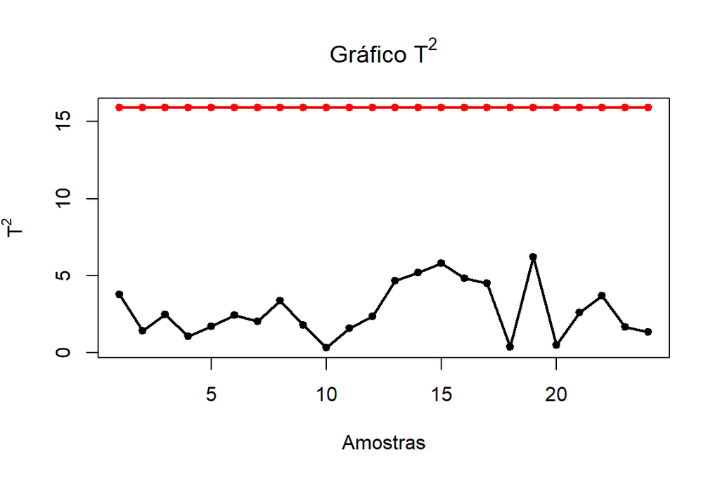

```
## $`Vetor de Médias`
## [1]  0.9010083 56.1203333  3.6040833
##
## $`Matriz de Covariâncias`
##              [,1]       [,2]        [,3]
## [1,] 0.0007502125 0.04765871 0.001352919
## [2,] 0.0476587083 4.53894032 0.159904244
## [3,] 0.0013529188 0.15990424 0.010140242
##
## $`Limite Superior de Controle`
## [1] 15.88585
```

```r
# n = número de observações por amostra
# y = matriz com os dados coletados (cada coluna deve se referir a uma variável)
# etapa = variável dicotômica que deve assumir o valor 1 caso se deseje construir
# o gráfico T2 para identificar as amostras fora de controle e 2, caso se deseje
# estabelecer quais são as estimativas do vetor de médias, da matriz de covariâncias
# e do limite superior de controle, visando o monitoramento futuro do processo.

dados11 <- dados1[-(96:100), ]
T2se(5, dados11, 2)
```

É possível verificar acima, na saída do R, as estimativas do vetor de médias e da matriz de covariâncias calculadas a partir das 24 amostras, que encontram-se sob controle. Calculou-se também o Limite Superior de Controle a ser utilizado em análises futuras, a saber, $LSC = 15,88585$.